[video not shown]

# The Boston Housing Dataset

```python
import pandas as pd
import numpy as np
import matplotlib.pyplot as plt
import seaborn as sns
%matplotlib inline
```

```python
from sklearn.datasets import fetch_openml

boston = fetch_openml(name='boston')
```

```python
boston.keys()
```

```
dict_keys(['data', 'target', 'frame', 'categories', 'feature_names', 'target_names', 'DESCR', 'details', 'url'])
```

```python
boston
```

[output not shown]

[output cut: 48 more lines]

[output not shown]

```python
print(boston['feature_names'])
```

```
['CRIM', 'ZN', 'INDUS', 'CHAS', 'NOX', 'RM', 'AGE', 'DIS', 'RAD', 'TAX', 'PTRATIO', 'B', 'LSTAT']
```

```python
boston_df = pd.DataFrame(boston.data, columns=boston.feature_names)
boston_df['target'] = boston.target
```

```python
boston_df
```

|  | CRIM | ZN | INDUS | CHAS | NOX | RM | AGE | DIS | RAD | TAX | PTRATIO | B | LSTAT | target |
| --- | --- | --- | --- | --- | --- | --- | --- | --- | --- | --- | --- | --- | --- | --- |
| 0 | 0.00632 | 18.0 | 2.31 | 0 | 0.538 | 6.575 | 65.2 | 4.0900 | 1 | 296.0 | 15.3 | 396.90 | 4.98 | 24.0 |
| 1 | 0.02731 | 0.0 | 7.07 | 0 | 0.469 | 6.421 | 78.9 | 4.9671 | 2 | 242.0 | 17.8 | 396.90 | 9.14 | 21.6 |
| 2 | 0.02729 | 0.0 | 7.07 | 0 | 0.469 | 7.185 | 61.1 | 4.9671 | 2 | 242.0 | 17.8 | 392.83 | 4.03 | 34.7 |
| 3 | 0.03237 | 0.0 | 2.18 | 0 | 0.458 | 6.998 | 45.8 | 6.0622 | 3 | 222.0 | 18.7 | 394.63 | 2.94 | 33.4 |
| 4 | 0.06905 | 0.0 | 2.18 | 0 | 0.458 | 7.147 | 54.2 | 6.0622 | 3 | 222.0 | 18.7 | 396.90 | 5.33 | 36.2 |
| ... | ... | ... | ... | ... | ... | ... | ... | ... | ... | ... | ... | ... | ... | ... |
| 501 | 0.06263 | 0.0 | 11.93 | 0 | 0.573 | 6.593 | 69.1 | 2.4786 | 1 | 273.0 | 21.0 | 391.99 | 9.67 | 22.4 |
| 502 | 0.04527 | 0.0 | 11.93 | 0 | 0.573 | 6.120 | 76.7 | 2.2875 | 1 | 273.0 | 21.0 | 396.90 | 9.08 | 20.6 |
| 503 | 0.06076 | 0.0 | 11.93 | 0 | 0.573 | 6.976 | 91.0 | 2.1675 | 1 | 273.0 | 21.0 | 396.90 | 5.64 | 23.9 |
| 504 | 0.10959 | 0.0 | 11.93 | 0 | 0.573 | 6.794 | 89.3 | 2.3889 | 1 | 273.0 | 21.0 | 393.45 | 6.48 | 22.0 |
| 505 | 0.04741 | 0.0 | 11.93 | 0 | 0.573 | 6.030 | 80.8 | 2.5050 | 1 | 273.0 | 21.0 | 396.90 | 7.88 | 11.9 |

506 rows × 14 columns

**Features**

- CRIM: crime rate in the area
- ZN: proportion of land zoned for residential use
- INDUS: proportion of land zoned for industrial use
- CHAS: whether the area is adjacent to the Charles River (1 if yes, 0 if no)
- NOX: air pollution level
- RM: average number of rooms per dwelling
- AGE: proportion of homes built before 1940
- DIS: distance to employment centers
- RAD: accessibility to highways
- TAX: property tax rate
- PTRATIO: student-to-teacher ratio in schools
- B: proportion of Black residents in the area
- LSTAT: percentage of lower status residents in the area

```python
boston_df.describe()
```

|  | CRIM | ZN | INDUS | NOX | RM | AGE | DIS | TAX | PTRATIO | B | LSTAT | target |
| --- | --- | --- | --- | --- | --- | --- | --- | --- | --- | --- | --- | --- |
| count | 506.000000 | 506.000000 | 506.000000 | 506.000000 | 506.000000 | 506.000000 | 506.000000 | 506.000000 | 506.000000 | 506.000000 | 506.000000 | 506.000000 |
| mean | 3.613524 | 11.363636 | 11.136779 | 0.554695 | 6.284634 | 68.574901 | 3.795043 | 408.237154 | 18.455534 | 356.674032 | 12.653063 | 22.532806 |
| std | 8.601545 | 23.322453 | 6.860353 | 0.115878 | 0.702617 | 28.148861 | 2.105710 | 168.537116 | 2.164946 | 91.294864 | 7.141062 | 9.197104 |
| min | 0.006320 | 0.000000 | 0.460000 | 0.385000 | 3.561000 | 2.900000 | 1.129600 | 187.000000 | 12.600000 | 0.320000 | 1.730000 | 5.000000 |
| 25% | 0.082045 | 0.000000 | 5.190000 | 0.449000 | 5.885500 | 45.025000 | 2.100175 | 279.000000 | 17.400000 | 375.377500 | 6.950000 | 17.025000 |
| 50% | 0.256510 | 0.000000 | 9.690000 | 0.538000 | 6.208500 | 77.500000 | 3.207450 | 330.000000 | 19.050000 | 391.440000 | 11.360000 | 21.200000 |
| 75% | 3.677083 | 12.500000 | 18.100000 | 0.624000 | 6.623500 | 94.075000 | 5.188425 | 666.000000 | 20.200000 | 396.225000 | 16.955000 | 25.000000 |
| max | 88.976200 | 100.000000 | 27.740000 | 0.871000 | 8.780000 | 100.000000 | 12.126500 | 711.000000 | 22.000000 | 396.900000 | 37.970000 | 50.000000 |

```python
boston_df.columns
```

```
Index(['CRIM', 'ZN', 'INDUS', 'CHAS', 'NOX', 'RM', 'AGE', 'DIS', 'RAD', 'TAX',
       'PTRATIO', 'B', 'LSTAT', 'target'],
      dtype='object')
```

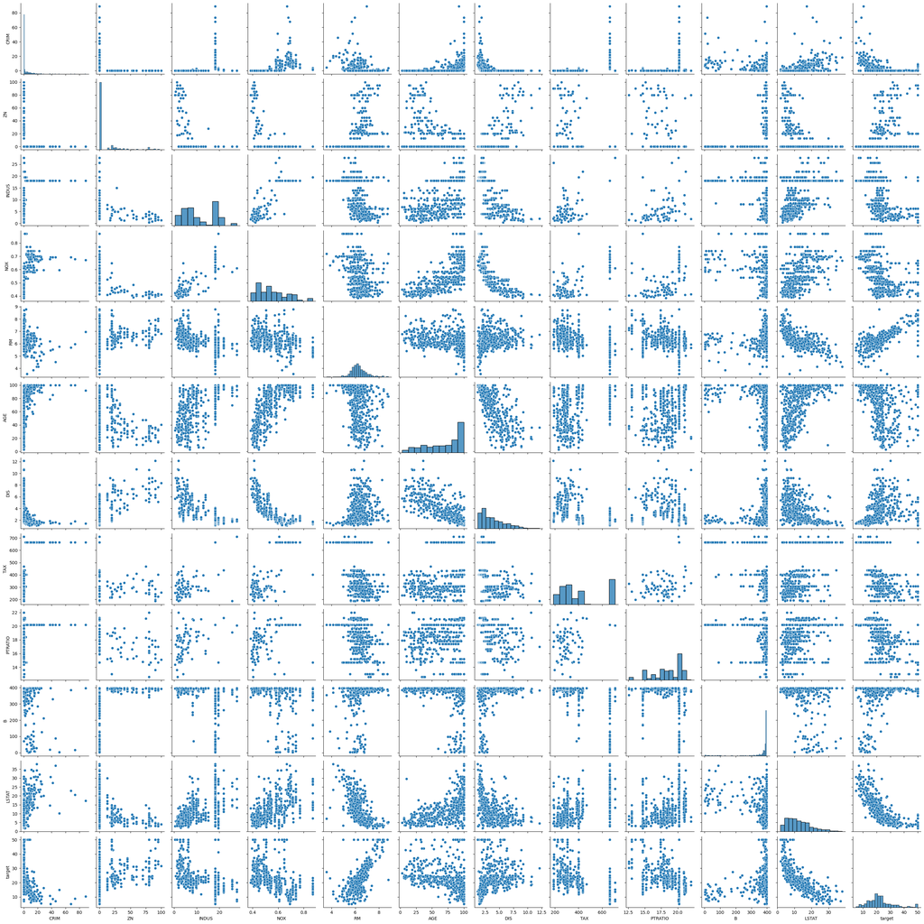

```python
sns.pairplot(boston_df)
```

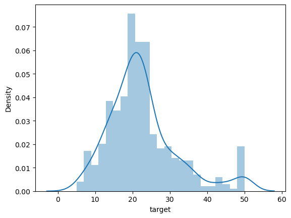

```python
sns.distplot(boston_df['target'])
```

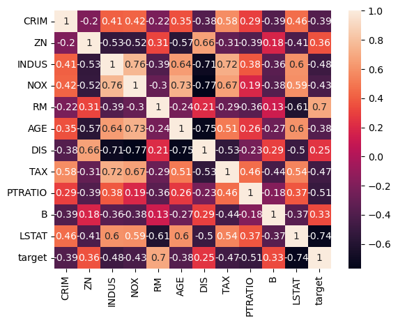

```python
sns.heatmap(boston_df.corr(), annot=True)
```

```python
boston_df.columns
```

```
Index(['CRIM', 'ZN', 'INDUS', 'CHAS', 'NOX', 'RM', 'AGE', 'DIS', 'RAD', 'TAX',
       'PTRATIO', 'B', 'LSTAT', 'target'],
      dtype='object')
```

```python
x=boston_df[['CRIM', 'ZN', 'INDUS','NOX', 'RM', 'AGE', 'DIS',  'TAX',
       'PTRATIO', 'B', 'LSTAT']]
y=boston_df['target']
```

Spliting the data into training set and testing set, sklearn have a function to do that

```python
from sklearn.model_selection import train_test_split
```

```python
x_train, x_test, y_train, y_test = train_test_split(x,y, test_size=0.4, random_state=40)
```

```python
from sklearn.linear_model import LinearRegression
```

```python
lm= LinearRegression()
```

```python
lm.fit(x_train, y_train)
```

```
LinearRegression()
```

```python
print(lm.intercept_)
```

```
32.67634711958024
```

**Note:** the intercept is the value where the regression line crosses the y-axis. It represents the predicted value of the dependent variable when all independent variables are equal to zero.

```python
 lm.coef_
```

```
array([-3.51786099e-03,  3.72696165e-02, -8.89433616e-02, -1.53308478e+01,
        4.10707959e+00, -1.29447934e-02, -1.41777525e+00, -9.37944355e-04,
       -9.04918826e-01,  5.97224878e-03, -4.73388513e-01])
```

```python
x_train.columns
```

```
Index(['CRIM', 'ZN', 'INDUS', 'NOX', 'RM', 'AGE', 'DIS', 'TAX', 'PTRATIO', 'B',
       'LSTAT'],
      dtype='object')
```

```python
coeff_df = pd.DataFrame(lm.coef_, x_train.columns, columns=['Coeff'])
coeff_df
```

|  | Coeff |
| --- | --- |
| CRIM | -0.003518 |
| ZN | 0.037270 |
| INDUS | -0.088943 |
| NOX | -15.330848 |
| RM | 4.107080 |
| AGE | -0.012945 |
| DIS | -1.417775 |
| TAX | -0.000938 |
| PTRATIO | -0.904919 |
| B | 0.005972 |
| LSTAT | -0.473389 |

## Predections

```python
predections = lm.predict(x_test)
```

```python
predections
```

```
array([17.49079953, 34.01120326,  9.17947622, 16.17957971, 17.33412796,
       27.21561606, 25.91039612, 16.82799487, 20.1053072 , -0.68704331,
       22.48730809, 15.71819642,  4.98312632,  6.05948703, 25.88541812,
       36.1796925 , 26.32620011, 18.59540161, 24.7160642 , 15.94076313,
       40.7902119 , 11.05195161, 37.062973  , 26.18596203, 39.10861392,
       25.26570816, 22.05582168, 20.20975157, 19.62505639, 18.77722044,
       24.62037621, 23.32280689, 31.14509088, 25.02394944,  0.34078985,
       24.92416252, 25.45582457, 11.34970356, 40.71110912, 28.55487427,
       22.69126368,  9.73014907, 21.31797943, 21.53028979, 32.5657528 ,
        7.53827693, 12.92902779, 32.37701152, 20.39941782, 36.71299491,
       14.30855238, 21.21089533, 18.98350832, 12.74505329, 12.4467971 ,
       38.8383467 , 26.22227852, 20.33154179, 23.81454195,  9.17483488,
       22.87830658, 10.62926224, 33.0844706 , 14.69239361, 28.79088632,
       17.84357364,  4.92233201, 28.84930336, 15.49390002, 17.50875756,
       19.61535882, 27.88572399, 20.37671776, 28.23455138, 35.84344264,
       19.55410309, 13.73399829, 24.94571585, 17.15415548, 25.21932342,
       18.1743897 , 13.7445385 , 18.30975271, 10.46994644, 16.13062957,
       10.53762518, 18.06786591, 21.4114125 , 18.74327215, 17.85445528,
       27.73795386,  9.35925331, 20.27479938,  5.73307375, 21.29121382,
        5.80213013, 16.6544465 , 26.99508443, 23.30168233, 21.45120457,
       23.65219006, 17.84927486, 25.1804514 ,  5.60695366, 32.64439322,
       21.22071235, 31.02519818, 32.89061471, 23.57688353, 17.65507664,
       30.65123156, 40.74666165, 27.88432823, 23.25814685, 21.75886253,
       16.69275862, 20.75983235, 21.03727045, 42.38321739, 20.1168363 ,
       22.78659376, 28.58470338, 24.14453902, 15.90477556, 43.10920354,
       17.51901475, 21.20603091, 24.50454135, 15.97178098, 28.7235265 ,
       14.37278969, 26.66468482, 30.76024689, 22.98990534, 34.16546495,
       35.32428516, 19.4361711 , 21.27127889, 11.08700387, 19.82994005,
       12.59148077, 36.84543581, 18.29327389, 26.43654346, 26.19640123,
       22.67227582, 12.58613187, 19.86677604, 15.94865186, 34.47008309,
       32.82707201, 14.12885912, 20.97929269, 18.40626767, 24.69945457,
       21.64458906, 28.44349484, 15.86557433, 16.96055754, 22.86510898,
       17.64987542, 31.65829841, 16.71241665, 26.39861109, 20.27032276,
       31.8194015 , 21.12364043, 21.15251115, 19.02153728, 15.43146191,
       33.42195386, 17.40576072, 28.62698896, 32.66949183, 17.18161484,
       16.15239969, 28.50870578, 22.70915083, 19.98020208, 28.86551749,
       19.64952426, 25.22347847, 14.30859196, 12.81177651, 15.4346676 ,
       24.26093837, 23.87164654, 22.542482  , 28.34881325, 17.86294864,
       11.64247466, 29.31620529, 25.42162984, 31.09198465, 27.80223703,
       30.04953603, 22.88670936, 34.36044298, 18.22091386, 17.05195146,
       33.12304485, 36.49295342, 34.14630898])
```

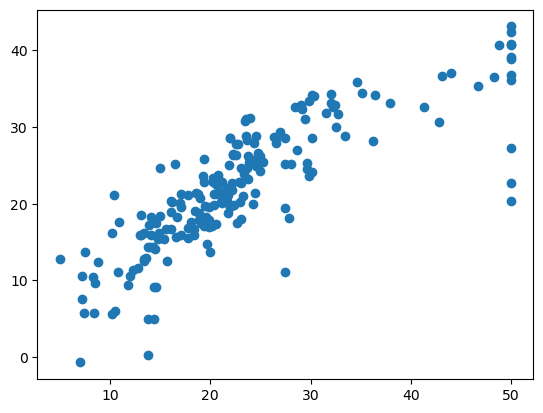

```python
plt.scatter(y_test, predections)
```

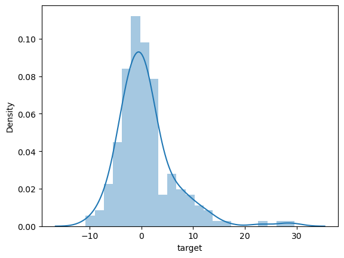

```python
sns.distplot(y_test-predections)
```

## Regression Evaluation Metrics

**Mean Absolute Error** (MAE) is the mean of the absolute value of the errors:

$$\frac 1n\sum_{i=1}^n|y_i-\hat{y}_i|$$

**Mean Squared Error** (MSE) is the mean of the squared errors:

$$\frac 1n\sum_{i=1}^n(y_i-\hat{y}_i)^2$$

**Root Mean Squared Error** (RMSE) is the square root of the mean of the squared errors:

$$\sqrt{\frac 1n\sum_{i=1}^n(y_i-\hat{y}_i)^2}$$

All of these are **loss functions**, because we want to minimize them.

```python
from sklearn import metrics
```

```python
metrics.mean_absolute_error(y_test, predections)
```

```
3.818274800638874
```

```python
metrics.mean_squared_error(y_test, predections)
```

```
32.306239407343625
```

```python
np.sqrt(metrics.mean_squared_error(y_test, predections))
```

```
5.683857792674234
```